# Risk Factor Analysis

## Outcome Variable

**Outcome Variable:** ever_stunted

## Predictor Variables

**Intervention Variable:** gagebrth

**Adjustment Set:**

- arm
- W_mage
- meducyrs
- feducyrs
- hhwealth_quart
- single
- brthmon
- W_parity
- delta_W_mage
- delta_meducyrs
- delta_feducyrs
- delta_hhwealth_quart
- delta_single
- delta_brthmon
- delta_W_parity

## Stratifying Variables

The analysis was stratified on these variable(s):

- agecat
- studyid
- country

## Data Summary

| agecat | studyid | country | gagebrth | ever_stunted | n_cell | n |
| --- | --- | --- | --- | --- | --- | --- |
| 0-24 months (no birth st.) | ki1000108-CMC-V-BCS-2002 | INDIA | Full or late term | 0 | 18 | 278 |
| 0-24 months (no birth st.) | ki1000108-CMC-V-BCS-2002 | INDIA | Full or late term | 1 | 164 | 278 |
| 0-24 months (no birth st.) | ki1000108-CMC-V-BCS-2002 | INDIA | Preterm | 0 | 3 | 278 |
| 0-24 months (no birth st.) | ki1000108-CMC-V-BCS-2002 | INDIA | Preterm | 1 | 30 | 278 |
| 0-24 months (no birth st.) | ki1000108-CMC-V-BCS-2002 | INDIA | Early term | 0 | 7 | 278 |
| 0-24 months (no birth st.) | ki1000108-CMC-V-BCS-2002 | INDIA | Early term | 1 | 56 | 278 |
| 0-24 months (no birth st.) | ki1000108-IRC | INDIA | Full or late term | 0 | 95 | 341 |
| 0-24 months (no birth st.) | ki1000108-IRC | INDIA | Full or late term | 1 | 126 | 341 |
| 0-24 months (no birth st.) | ki1000108-IRC | INDIA | Preterm | 0 | 9 | 341 |
| 0-24 months (no birth st.) | ki1000108-IRC | INDIA | Preterm | 1 | 23 | 341 |
| 0-24 months (no birth st.) | ki1000108-IRC | INDIA | Early term | 0 | 34 | 341 |
| 0-24 months (no birth st.) | ki1000108-IRC | INDIA | Early term | 1 | 54 | 341 |
| 0-24 months (no birth st.) | ki1000109-EE | PAKISTAN | Full or late term | 0 | 2 | 213 |
| 0-24 months (no birth st.) | ki1000109-EE | PAKISTAN | Full or late term | 1 | 8 | 213 |
| 0-24 months (no birth st.) | ki1000109-EE | PAKISTAN | Preterm | 0 | 30 | 213 |
| 0-24 months (no birth st.) | ki1000109-EE | PAKISTAN | Preterm | 1 | 141 | 213 |
| 0-24 months (no birth st.) | ki1000109-EE | PAKISTAN | Early term | 0 | 9 | 213 |
| 0-24 months (no birth st.) | ki1000109-EE | PAKISTAN | Early term | 1 | 23 | 213 |
| 0-24 months (no birth st.) | ki1017093c-NIH-Crypto | BANGLADESH | Full or late term | 0 | 105 | 653 |
| 0-24 months (no birth st.) | ki1017093c-NIH-Crypto | BANGLADESH | Full or late term | 1 | 51 | 653 |
| 0-24 months (no birth st.) | ki1017093c-NIH-Crypto | BANGLADESH | Preterm | 0 | 110 | 653 |
| 0-24 months (no birth st.) | ki1017093c-NIH-Crypto | BANGLADESH | Preterm | 1 | 89 | 653 |
| 0-24 months (no birth st.) | ki1017093c-NIH-Crypto | BANGLADESH | Early term | 0 | 181 | 653 |
| 0-24 months (no birth st.) | ki1017093c-NIH-Crypto | BANGLADESH | Early term | 1 | 117 | 653 |
| 0-24 months (no birth st.) | ki1066203-TanzaniaChild2 | TANZANIA, UNITED REPUBLIC OF | Full or late term | 0 | 944 | 2101 |
| 0-24 months (no birth st.) | ki1066203-TanzaniaChild2 | TANZANIA, UNITED REPUBLIC OF | Full or late term | 1 | 379 | 2101 |
| 0-24 months (no birth st.) | ki1066203-TanzaniaChild2 | TANZANIA, UNITED REPUBLIC OF | Preterm | 0 | 204 | 2101 |
| 0-24 months (no birth st.) | ki1066203-TanzaniaChild2 | TANZANIA, UNITED REPUBLIC OF | Preterm | 1 | 97 | 2101 |
| 0-24 months (no birth st.) | ki1066203-TanzaniaChild2 | TANZANIA, UNITED REPUBLIC OF | Early term | 0 | 327 | 2101 |
| 0-24 months (no birth st.) | ki1066203-TanzaniaChild2 | TANZANIA, UNITED REPUBLIC OF | Early term | 1 | 150 | 2101 |

[output cut: 168 more lines]

The following strata were considered:

- agecat: 0-24 months (no birth st.), studyid: ki1000108-CMC-V-BCS-2002, country: INDIA
- agecat: 0-24 months (no birth st.), studyid: ki1000108-IRC, country: INDIA
- agecat: 0-24 months (no birth st.), studyid: ki1000109-EE, country: PAKISTAN
- agecat: 0-24 months (no birth st.), studyid: ki1017093c-NIH-Crypto, country: BANGLADESH
- agecat: 0-24 months (no birth st.), studyid: ki1066203-TanzaniaChild2, country: TANZANIA, UNITED REPUBLIC OF
- agecat: 0-24 months (no birth st.), studyid: ki1101329-Keneba, country: GAMBIA
- agecat: 0-24 months (no birth st.), studyid: ki1119695-PROBIT, country: BELARUS
- agecat: 0-24 months (no birth st.), studyid: ki1135781-COHORTS, country: GUATEMALA
- agecat: 0-24 months (no birth st.), studyid: ki1135781-COHORTS, country: INDIA
- agecat: 0-24 months (no birth st.), studyid: ki1135781-COHORTS, country: PHILIPPINES
- agecat: 0-24 months (no birth st.), studyid: kiGH5241-JiVitA-3, country: BANGLADESH
- agecat: 0-6 months (no birth st.), studyid: ki1000108-CMC-V-BCS-2002, country: INDIA
- agecat: 0-6 months (no birth st.), studyid: ki1000108-IRC, country: INDIA
- agecat: 0-6 months (no birth st.), studyid: ki1000109-EE, country: PAKISTAN
- agecat: 0-6 months (no birth st.), studyid: ki1017093c-NIH-Crypto, country: BANGLADESH
- agecat: 0-6 months (no birth st.), studyid: ki1066203-TanzaniaChild2, country: TANZANIA, UNITED REPUBLIC OF
- agecat: 0-6 months (no birth st.), studyid: ki1101329-Keneba, country: GAMBIA
- agecat: 0-6 months (no birth st.), studyid: ki1119695-PROBIT, country: BELARUS
- agecat: 0-6 months (no birth st.), studyid: ki1135781-COHORTS, country: GUATEMALA
- agecat: 0-6 months (no birth st.), studyid: ki1135781-COHORTS, country: INDIA
- agecat: 0-6 months (no birth st.), studyid: ki1135781-COHORTS, country: PHILIPPINES
- agecat: 0-6 months (no birth st.), studyid: kiGH5241-JiVitA-3, country: BANGLADESH
- agecat: 6-24 months, studyid: ki1000108-CMC-V-BCS-2002, country: INDIA
- agecat: 6-24 months, studyid: ki1000108-IRC, country: INDIA
- agecat: 6-24 months, studyid: ki1000109-EE, country: PAKISTAN
- agecat: 6-24 months, studyid: ki1017093c-NIH-Crypto, country: BANGLADESH
- agecat: 6-24 months, studyid: ki1066203-TanzaniaChild2, country: TANZANIA, UNITED REPUBLIC OF
- agecat: 6-24 months, studyid: ki1101329-Keneba, country: GAMBIA
- agecat: 6-24 months, studyid: ki1119695-PROBIT, country: BELARUS
- agecat: 6-24 months, studyid: ki1135781-COHORTS, country: GUATEMALA
- agecat: 6-24 months, studyid: ki1135781-COHORTS, country: INDIA
- agecat: 6-24 months, studyid: ki1135781-COHORTS, country: PHILIPPINES
- agecat: 6-24 months, studyid: kiGH5241-JiVitA-3, country: BANGLADESH

### Dropped Strata

Some strata were dropped due to rare outcomes:

- agecat: 0-24 months (no birth st.), studyid: ki1000108-CMC-V-BCS-2002, country: INDIA
- agecat: 0-24 months (no birth st.), studyid: ki1000109-EE, country: PAKISTAN
- agecat: 0-6 months (no birth st.), studyid: ki1000109-EE, country: PAKISTAN
- agecat: 6-24 months, studyid: ki1000108-CMC-V-BCS-2002, country: INDIA
- agecat: 6-24 months, studyid: ki1000109-EE, country: PAKISTAN

## Methods Detail

We’re interested in the causal parameters $E[Y_a]$ for all values of $a \in \mathcal{A}$. These parameters represent the mean outcome if, possibly contrary to fact, we intervened to set all units to have $A=a$. Under the randomization and positivity assumptions, these are identified by the statistical parameters $\psi_a=E_W[E_{Y|A,W}(Y|A=a,W)]$. In addition, we’re interested in the mean of $Y$, $E[Y]$ under no intervention (the observed mean). We will estimate these parameters by using SuperLearner to fit the relevant likelihood factors – $E_{Y|A,W}(Y|A=a,W)$ and $p(A=a|W)$, and then updating our likelihood fit using a joint TMLE.

For unadjusted analyses ($W=\{\}$), initial likelihoods were estimated using Lrnr_glm to estimate the simple $E(Y|A)$ and Lrnr_mean to estimate $p(A)$. For adjusted analyses, a small library containing Lrnr_glmnet, Lrnr_xgboost, and Lrnr_mean was used.

Having estimated these parameters, we will then use the delta method to estimate relative risks and attributable risks relative to a prespecified baseline level of $A$.

# Results Detail

## Results Plots

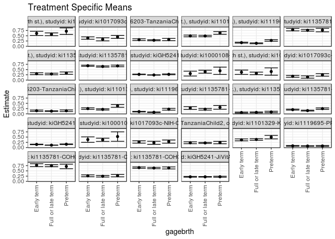

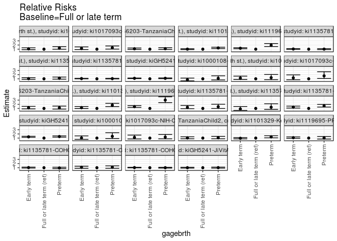

[figure not shown]

[figure not shown]

## Results Table

### Parameter: TSM

| agecat | studyid | country | intervention_level | baseline_level | estimate | ci_lower | ci_upper |
| --- | --- | --- | --- | --- | --- | --- | --- |
| 0-24 months (no birth st.) | ki1000108-IRC | INDIA | Full or late term | NA | 0.5701357 | 0.5047709 | 0.6355006 |
| 0-24 months (no birth st.) | ki1000108-IRC | INDIA | Preterm | NA | 0.7187500 | 0.5627423 | 0.8747577 |
| 0-24 months (no birth st.) | ki1000108-IRC | INDIA | Early term | NA | 0.6136364 | 0.5117542 | 0.7155185 |
| 0-24 months (no birth st.) | ki1017093c-NIH-Crypto | BANGLADESH | Full or late term | NA | 0.3304840 | 0.2563498 | 0.4046182 |
| 0-24 months (no birth st.) | ki1017093c-NIH-Crypto | BANGLADESH | Preterm | NA | 0.4457790 | 0.3762189 | 0.5153391 |
| 0-24 months (no birth st.) | ki1017093c-NIH-Crypto | BANGLADESH | Early term | NA | 0.3917748 | 0.3359452 | 0.4476044 |
| 0-24 months (no birth st.) | ki1066203-TanzaniaChild2 | TANZANIA, UNITED REPUBLIC OF | Full or late term | NA | 0.2866689 | 0.2622866 | 0.3110511 |
| 0-24 months (no birth st.) | ki1066203-TanzaniaChild2 | TANZANIA, UNITED REPUBLIC OF | Preterm | NA | 0.3203874 | 0.2673346 | 0.3734402 |
| 0-24 months (no birth st.) | ki1066203-TanzaniaChild2 | TANZANIA, UNITED REPUBLIC OF | Early term | NA | 0.3142828 | 0.2724307 | 0.3561348 |
| 0-24 months (no birth st.) | ki1101329-Keneba | GAMBIA | Full or late term | NA | 0.4891995 | 0.4547726 | 0.5236264 |
| 0-24 months (no birth st.) | ki1101329-Keneba | GAMBIA | Preterm | NA | 0.6349095 | 0.5708268 | 0.6989921 |
| 0-24 months (no birth st.) | ki1101329-Keneba | GAMBIA | Early term | NA | 0.4920095 | 0.4507800 | 0.5332390 |
| 0-24 months (no birth st.) | ki1119695-PROBIT | BELARUS | Full or late term | NA | 0.1410131 | 0.1208435 | 0.1611827 |
| 0-24 months (no birth st.) | ki1119695-PROBIT | BELARUS | Preterm | NA | 0.2764498 | 0.2386961 | 0.3142035 |
| 0-24 months (no birth st.) | ki1119695-PROBIT | BELARUS | Early term | NA | 0.1720767 | 0.1502036 | 0.1939497 |
| 0-24 months (no birth st.) | ki1135781-COHORTS | GUATEMALA | Full or late term | NA | 0.7626475 | 0.7208110 | 0.8044840 |
| 0-24 months (no birth st.) | ki1135781-COHORTS | GUATEMALA | Preterm | NA | 0.7720282 | 0.6896518 | 0.8544046 |
| 0-24 months (no birth st.) | ki1135781-COHORTS | GUATEMALA | Early term | NA | 0.7910485 | 0.7335579 | 0.8485392 |
| 0-24 months (no birth st.) | ki1135781-COHORTS | INDIA | Full or late term | NA | 0.2877697 | 0.2503219 | 0.3252175 |
| 0-24 months (no birth st.) | ki1135781-COHORTS | INDIA | Preterm | NA | 0.3295385 | 0.2731523 | 0.3859247 |
| 0-24 months (no birth st.) | ki1135781-COHORTS | INDIA | Early term | NA | 0.3006347 | 0.2566269 | 0.3446425 |
| 0-24 months (no birth st.) | ki1135781-COHORTS | PHILIPPINES | Full or late term | NA | 0.6465121 | 0.6190629 | 0.6739612 |
| 0-24 months (no birth st.) | ki1135781-COHORTS | PHILIPPINES | Preterm | NA | 0.6734612 | 0.6348756 | 0.7120467 |
| 0-24 months (no birth st.) | ki1135781-COHORTS | PHILIPPINES | Early term | NA | 0.6818185 | 0.6549597 | 0.7086773 |
| 0-24 months (no birth st.) | kiGH5241-JiVitA-3 | BANGLADESH | Full or late term | NA | 0.2416064 | 0.2318296 | 0.2513832 |
| 0-24 months (no birth st.) | kiGH5241-JiVitA-3 | BANGLADESH | Preterm | NA | 0.2704706 | 0.2509025 | 0.2900387 |
| 0-24 months (no birth st.) | kiGH5241-JiVitA-3 | BANGLADESH | Early term | NA | 0.2702219 | 0.2560180 | 0.2844258 |
| 0-6 months (no birth st.) | ki1000108-CMC-V-BCS-2002 | INDIA | Full or late term | NA | 0.3968504 | 0.3248601 | 0.4688407 |
| 0-6 months (no birth st.) | ki1000108-CMC-V-BCS-2002 | INDIA | Preterm | NA | 0.4425473 | 0.2678294 | 0.6172651 |
| 0-6 months (no birth st.) | ki1000108-CMC-V-BCS-2002 | INDIA | Early term | NA | 0.3078980 | 0.1925200 | 0.4232760 |

[output cut: 54 more lines]

### Parameter: E(Y)

| agecat | studyid | country | intervention_level | baseline_level | estimate | ci_lower | ci_upper |
| --- | --- | --- | --- | --- | --- | --- | --- |
| 0-24 months (no birth st.) | ki1000108-IRC | INDIA | NA | NA | 0.5953079 | 0.5431354 | 0.6474804 |
| 0-24 months (no birth st.) | ki1017093c-NIH-Crypto | BANGLADESH | NA | NA | 0.3935681 | 0.3560687 | 0.4310676 |
| 0-24 months (no birth st.) | ki1066203-TanzaniaChild2 | TANZANIA, UNITED REPUBLIC OF | NA | NA | 0.2979534 | 0.2783922 | 0.3175146 |
| 0-24 months (no birth st.) | ki1101329-Keneba | GAMBIA | NA | NA | 0.5091714 | 0.4845214 | 0.5338214 |
| 0-24 months (no birth st.) | ki1119695-PROBIT | BELARUS | NA | NA | 0.1597778 | 0.1408215 | 0.1787342 |
| 0-24 months (no birth st.) | ki1135781-COHORTS | GUATEMALA | NA | NA | 0.7723343 | 0.7411143 | 0.8035543 |
| 0-24 months (no birth st.) | ki1135781-COHORTS | INDIA | NA | NA | 0.3004847 | 0.2749357 | 0.3260336 |
| 0-24 months (no birth st.) | ki1135781-COHORTS | PHILIPPINES | NA | NA | 0.6661982 | 0.6488700 | 0.6835264 |
| 0-24 months (no birth st.) | kiGH5241-JiVitA-3 | BANGLADESH | NA | NA | 0.2533685 | 0.2454041 | 0.2613329 |
| 0-6 months (no birth st.) | ki1000108-CMC-V-BCS-2002 | INDIA | NA | NA | 0.3795620 | 0.3219972 | 0.4371269 |
| 0-6 months (no birth st.) | ki1000108-IRC | INDIA | NA | NA | 0.3401760 | 0.2898173 | 0.3905347 |
| 0-6 months (no birth st.) | ki1017093c-NIH-Crypto | BANGLADESH | NA | NA | 0.1898928 | 0.1597870 | 0.2199986 |
| 0-6 months (no birth st.) | ki1066203-TanzaniaChild2 | TANZANIA, UNITED REPUBLIC OF | NA | NA | 0.1346978 | 0.1200961 | 0.1492994 |
| 0-6 months (no birth st.) | ki1101329-Keneba | GAMBIA | NA | NA | 0.2466667 | 0.2248446 | 0.2684887 |
| 0-6 months (no birth st.) | ki1119695-PROBIT | BELARUS | NA | NA | 0.0912784 | 0.0781588 | 0.1043979 |
| 0-6 months (no birth st.) | ki1135781-COHORTS | GUATEMALA | NA | NA | 0.2481315 | 0.2153770 | 0.2808861 |
| 0-6 months (no birth st.) | ki1135781-COHORTS | INDIA | NA | NA | 0.0687398 | 0.0545482 | 0.0829313 |
| 0-6 months (no birth st.) | ki1135781-COHORTS | PHILIPPINES | NA | NA | 0.1897400 | 0.1753322 | 0.2041478 |
| 0-6 months (no birth st.) | kiGH5241-JiVitA-3 | BANGLADESH | NA | NA | 0.1315668 | 0.1257634 | 0.1373703 |
| 6-24 months | ki1000108-IRC | INDIA | NA | NA | 0.3866667 | 0.3228931 | 0.4504402 |
| 6-24 months | ki1017093c-NIH-Crypto | BANGLADESH | NA | NA | 0.2628458 | 0.2244546 | 0.3012371 |
| 6-24 months | ki1066203-TanzaniaChild2 | TANZANIA, UNITED REPUBLIC OF | NA | NA | 0.2274536 | 0.2062895 | 0.2486177 |
| 6-24 months | ki1101329-Keneba | GAMBIA | NA | NA | 0.3917012 | 0.3641291 | 0.4192734 |
| 6-24 months | ki1119695-PROBIT | BELARUS | NA | NA | 0.0768510 | 0.0628857 | 0.0908164 |
| 6-24 months | ki1135781-COHORTS | GUATEMALA | NA | NA | 0.7490347 | 0.7116615 | 0.7864080 |
| 6-24 months | ki1135781-COHORTS | INDIA | NA | NA | 0.2598214 | 0.2341270 | 0.2855158 |
| 6-24 months | ki1135781-COHORTS | PHILIPPINES | NA | NA | 0.6444867 | 0.6240287 | 0.6649447 |
| 6-24 months | kiGH5241-JiVitA-3 | BANGLADESH | NA | NA | 0.2163549 | 0.2067486 | 0.2259611 |

### Parameter: RR

| agecat | studyid | country | intervention_level | baseline_level | estimate | ci_lower | ci_upper |
| --- | --- | --- | --- | --- | --- | --- | --- |
| 0-24 months (no birth st.) | ki1000108-IRC | INDIA | Full or late term | Full or late term | 1.0000000 | 1.0000000 | 1.000000 |
| 0-24 months (no birth st.) | ki1000108-IRC | INDIA | Preterm | Full or late term | 1.2606647 | 0.9862620 | 1.611413 |
| 0-24 months (no birth st.) | ki1000108-IRC | INDIA | Early term | Full or late term | 1.0762987 | 0.8796426 | 1.316920 |
| 0-24 months (no birth st.) | ki1017093c-NIH-Crypto | BANGLADESH | Full or late term | Full or late term | 1.0000000 | 1.0000000 | 1.000000 |
| 0-24 months (no birth st.) | ki1017093c-NIH-Crypto | BANGLADESH | Preterm | Full or late term | 1.3488672 | 1.0265500 | 1.772386 |
| 0-24 months (no birth st.) | ki1017093c-NIH-Crypto | BANGLADESH | Early term | Full or late term | 1.1854578 | 0.9090083 | 1.545982 |
| 0-24 months (no birth st.) | ki1066203-TanzaniaChild2 | TANZANIA, UNITED REPUBLIC OF | Full or late term | Full or late term | 1.0000000 | 1.0000000 | 1.000000 |
| 0-24 months (no birth st.) | ki1066203-TanzaniaChild2 | TANZANIA, UNITED REPUBLIC OF | Preterm | Full or late term | 1.1176219 | 0.9277767 | 1.346314 |
| 0-24 months (no birth st.) | ki1066203-TanzaniaChild2 | TANZANIA, UNITED REPUBLIC OF | Early term | Full or late term | 1.0963268 | 0.9360638 | 1.284028 |
| 0-24 months (no birth st.) | ki1101329-Keneba | GAMBIA | Full or late term | Full or late term | 1.0000000 | 1.0000000 | 1.000000 |
| 0-24 months (no birth st.) | ki1101329-Keneba | GAMBIA | Preterm | Full or late term | 1.2978539 | 1.1481708 | 1.467051 |
| 0-24 months (no birth st.) | ki1101329-Keneba | GAMBIA | Early term | Full or late term | 1.0057440 | 0.9017898 | 1.121682 |
| 0-24 months (no birth st.) | ki1119695-PROBIT | BELARUS | Full or late term | Full or late term | 1.0000000 | 1.0000000 | 1.000000 |
| 0-24 months (no birth st.) | ki1119695-PROBIT | BELARUS | Preterm | Full or late term | 1.9604552 | 1.6303735 | 2.357364 |
| 0-24 months (no birth st.) | ki1119695-PROBIT | BELARUS | Early term | Full or late term | 1.2202887 | 1.1012333 | 1.352215 |
| 0-24 months (no birth st.) | ki1135781-COHORTS | GUATEMALA | Full or late term | Full or late term | 1.0000000 | 1.0000000 | 1.000000 |
| 0-24 months (no birth st.) | ki1135781-COHORTS | GUATEMALA | Preterm | Full or late term | 1.0123002 | 0.8979131 | 1.141259 |
| 0-24 months (no birth st.) | ki1135781-COHORTS | GUATEMALA | Early term | Full or late term | 1.0372401 | 0.9469650 | 1.136121 |
| 0-24 months (no birth st.) | ki1135781-COHORTS | INDIA | Full or late term | Full or late term | 1.0000000 | 1.0000000 | 1.000000 |
| 0-24 months (no birth st.) | ki1135781-COHORTS | INDIA | Preterm | Full or late term | 1.1451467 | 0.9239813 | 1.419250 |
| 0-24 months (no birth st.) | ki1135781-COHORTS | INDIA | Early term | Full or late term | 1.0447058 | 0.8596717 | 1.269566 |
| 0-24 months (no birth st.) | ki1135781-COHORTS | PHILIPPINES | Full or late term | Full or late term | 1.0000000 | 1.0000000 | 1.000000 |
| 0-24 months (no birth st.) | ki1135781-COHORTS | PHILIPPINES | Preterm | Full or late term | 1.0416838 | 0.9702915 | 1.118329 |
| 0-24 months (no birth st.) | ki1135781-COHORTS | PHILIPPINES | Early term | Full or late term | 1.0546106 | 0.9956858 | 1.117023 |
| 0-24 months (no birth st.) | kiGH5241-JiVitA-3 | BANGLADESH | Full or late term | Full or late term | 1.0000000 | 1.0000000 | 1.000000 |
| 0-24 months (no birth st.) | kiGH5241-JiVitA-3 | BANGLADESH | Preterm | Full or late term | 1.1194680 | 1.0326844 | 1.213545 |
| 0-24 months (no birth st.) | kiGH5241-JiVitA-3 | BANGLADESH | Early term | Full or late term | 1.1184386 | 1.0503515 | 1.190939 |
| 0-6 months (no birth st.) | ki1000108-CMC-V-BCS-2002 | INDIA | Full or late term | Full or late term | 1.0000000 | 1.0000000 | 1.000000 |
| 0-6 months (no birth st.) | ki1000108-CMC-V-BCS-2002 | INDIA | Preterm | Full or late term | 1.1151487 | 0.7219505 | 1.722496 |
| 0-6 months (no birth st.) | ki1000108-CMC-V-BCS-2002 | INDIA | Early term | Full or late term | 0.7758540 | 0.5111186 | 1.177710 |

[output cut: 54 more lines]

### Parameter: PAR

| agecat | studyid | country | intervention_level | baseline_level | estimate | ci_lower | ci_upper |
| --- | --- | --- | --- | --- | --- | --- | --- |
| 0-24 months (no birth st.) | ki1000108-IRC | INDIA | Full or late term | NA | 0.0251722 | -0.0129918 | 0.0633362 |
| 0-24 months (no birth st.) | ki1017093c-NIH-Crypto | BANGLADESH | Full or late term | NA | 0.0630842 | -0.0025244 | 0.1286927 |
| 0-24 months (no birth st.) | ki1066203-TanzaniaChild2 | TANZANIA, UNITED REPUBLIC OF | Full or late term | NA | 0.0112845 | -0.0038499 | 0.0264189 |
| 0-24 months (no birth st.) | ki1101329-Keneba | GAMBIA | Full or late term | NA | 0.0199719 | -0.0039944 | 0.0439382 |
| 0-24 months (no birth st.) | ki1119695-PROBIT | BELARUS | Full or late term | NA | 0.0187647 | 0.0113709 | 0.0261585 |
| 0-24 months (no birth st.) | ki1135781-COHORTS | GUATEMALA | Full or late term | NA | 0.0096868 | -0.0171649 | 0.0365386 |
| 0-24 months (no birth st.) | ki1135781-COHORTS | INDIA | Full or late term | NA | 0.0127150 | -0.0153157 | 0.0407456 |
| 0-24 months (no birth st.) | ki1135781-COHORTS | PHILIPPINES | Full or late term | NA | 0.0196861 | -0.0013886 | 0.0407608 |
| 0-24 months (no birth st.) | kiGH5241-JiVitA-3 | BANGLADESH | Full or late term | NA | 0.0117621 | 0.0059444 | 0.0175799 |
| 0-6 months (no birth st.) | ki1000108-CMC-V-BCS-2002 | INDIA | Full or late term | NA | -0.0172884 | -0.0591863 | 0.0246095 |
| 0-6 months (no birth st.) | ki1000108-IRC | INDIA | Full or late term | NA | 0.0225197 | -0.0156057 | 0.0606452 |
| 0-6 months (no birth st.) | ki1017093c-NIH-Crypto | BANGLADESH | Full or late term | NA | 0.0462015 | -0.0040428 | 0.0964459 |
| 0-6 months (no birth st.) | ki1066203-TanzaniaChild2 | TANZANIA, UNITED REPUBLIC OF | Full or late term | NA | 0.0075730 | -0.0038163 | 0.0189622 |
| 0-6 months (no birth st.) | ki1101329-Keneba | GAMBIA | Full or late term | NA | 0.0361575 | 0.0145162 | 0.0577988 |
| 0-6 months (no birth st.) | ki1119695-PROBIT | BELARUS | Full or late term | NA | 0.0191311 | 0.0133809 | 0.0248813 |
| 0-6 months (no birth st.) | ki1135781-COHORTS | GUATEMALA | Full or late term | NA | 0.0309557 | 0.0017100 | 0.0602014 |
| 0-6 months (no birth st.) | ki1135781-COHORTS | INDIA | Full or late term | NA | 0.0015596 | -0.0140326 | 0.0171519 |
| 0-6 months (no birth st.) | ki1135781-COHORTS | PHILIPPINES | Full or late term | NA | 0.0372181 | 0.0199788 | 0.0544574 |
| 0-6 months (no birth st.) | kiGH5241-JiVitA-3 | BANGLADESH | Full or late term | NA | 0.0156952 | 0.0110427 | 0.0203477 |
| 6-24 months | ki1000108-IRC | INDIA | Full or late term | NA | 0.0158057 | -0.0292126 | 0.0608240 |
| 6-24 months | ki1017093c-NIH-Crypto | BANGLADESH | Full or late term | NA | 0.0339647 | -0.0309941 | 0.0989236 |
| 6-24 months | ki1066203-TanzaniaChild2 | TANZANIA, UNITED REPUBLIC OF | Full or late term | NA | 0.0054935 | -0.0108664 | 0.0218535 |
| 6-24 months | ki1101329-Keneba | GAMBIA | Full or late term | NA | 0.0051568 | -0.0204573 | 0.0307709 |
| 6-24 months | ki1119695-PROBIT | BELARUS | Full or late term | NA | 0.0031406 | -0.0026570 | 0.0089381 |
| 6-24 months | ki1135781-COHORTS | GUATEMALA | Full or late term | NA | 0.0010461 | -0.0302066 | 0.0322987 |
| 6-24 months | ki1135781-COHORTS | INDIA | Full or late term | NA | 0.0165769 | -0.0115758 | 0.0447297 |
| 6-24 months | ki1135781-COHORTS | PHILIPPINES | Full or late term | NA | 0.0083735 | -0.0154037 | 0.0321507 |
| 6-24 months | kiGH5241-JiVitA-3 | BANGLADESH | Full or late term | NA | 0.0005919 | -0.0065606 | 0.0077445 |

### Parameter: PAF

| agecat | studyid | country | intervention_level | baseline_level | estimate | ci_lower | ci_upper |
| --- | --- | --- | --- | --- | --- | --- | --- |
| 0-24 months (no birth st.) | ki1000108-IRC | INDIA | Full or late term | NA | 0.0422843 | -0.0242259 | 0.1044755 |
| 0-24 months (no birth st.) | ki1017093c-NIH-Crypto | BANGLADESH | Full or late term | NA | 0.1602877 | -0.0241529 | 0.3115123 |
| 0-24 months (no birth st.) | ki1066203-TanzaniaChild2 | TANZANIA, UNITED REPUBLIC OF | Full or late term | NA | 0.0378734 | -0.0142740 | 0.0873397 |
| 0-24 months (no birth st.) | ki1101329-Keneba | GAMBIA | Full or late term | NA | 0.0392243 | -0.0090626 | 0.0852005 |
| 0-24 months (no birth st.) | ki1119695-PROBIT | BELARUS | Full or late term | NA | 0.1174427 | 0.0681304 | 0.1641455 |
| 0-24 months (no birth st.) | ki1135781-COHORTS | GUATEMALA | Full or late term | NA | 0.0125423 | -0.0228650 | 0.0467238 |
| 0-24 months (no birth st.) | ki1135781-COHORTS | INDIA | Full or late term | NA | 0.0423148 | -0.0556410 | 0.1311810 |
| 0-24 months (no birth st.) | ki1135781-COHORTS | PHILIPPINES | Full or late term | NA | 0.0295499 | -0.0026251 | 0.0606924 |
| 0-24 months (no birth st.) | kiGH5241-JiVitA-3 | BANGLADESH | Full or late term | NA | 0.0464231 | 0.0231627 | 0.0691296 |
| 0-6 months (no birth st.) | ki1000108-CMC-V-BCS-2002 | INDIA | Full or late term | NA | -0.0455483 | -0.1620304 | 0.0592576 |
| 0-6 months (no birth st.) | ki1000108-IRC | INDIA | Full or late term | NA | 0.0662002 | -0.0529138 | 0.1718391 |
| 0-6 months (no birth st.) | ki1017093c-NIH-Crypto | BANGLADESH | Full or late term | NA | 0.2433033 | -0.0706303 | 0.4651843 |
| 0-6 months (no birth st.) | ki1066203-TanzaniaChild2 | TANZANIA, UNITED REPUBLIC OF | Full or late term | NA | 0.0562219 | -0.0320797 | 0.1369686 |
| 0-6 months (no birth st.) | ki1101329-Keneba | GAMBIA | Full or late term | NA | 0.1465845 | 0.0546237 | 0.2295998 |
| 0-6 months (no birth st.) | ki1119695-PROBIT | BELARUS | Full or late term | NA | 0.2095904 | 0.1383793 | 0.2749160 |
| 0-6 months (no birth st.) | ki1135781-COHORTS | GUATEMALA | Full or late term | NA | 0.1247552 | -0.0009504 | 0.2346740 |
| 0-6 months (no birth st.) | ki1135781-COHORTS | INDIA | Full or late term | NA | 0.0226890 | -0.2325700 | 0.2250852 |
| 0-6 months (no birth st.) | ki1135781-COHORTS | PHILIPPINES | Full or late term | NA | 0.1961531 | 0.1007985 | 0.2813960 |
| 0-6 months (no birth st.) | kiGH5241-JiVitA-3 | BANGLADESH | Full or late term | NA | 0.1192947 | 0.0834689 | 0.1537201 |
| 6-24 months | ki1000108-IRC | INDIA | Full or late term | NA | 0.0408769 | -0.0829571 | 0.1505508 |
| 6-24 months | ki1017093c-NIH-Crypto | BANGLADESH | Full or late term | NA | 0.1292193 | -0.1562857 | 0.3442286 |
| 6-24 months | ki1066203-TanzaniaChild2 | TANZANIA, UNITED REPUBLIC OF | Full or late term | NA | 0.0241524 | -0.0504796 | 0.0934821 |
| 6-24 months | ki1101329-Keneba | GAMBIA | Full or late term | NA | 0.0131652 | -0.0544486 | 0.0764435 |
| 6-24 months | ki1119695-PROBIT | BELARUS | Full or late term | NA | 0.0408660 | -0.0349220 | 0.1111039 |
| 6-24 months | ki1135781-COHORTS | GUATEMALA | Full or late term | NA | 0.0013966 | -0.0412118 | 0.0422613 |
| 6-24 months | ki1135781-COHORTS | INDIA | Full or late term | NA | 0.0638013 | -0.0510416 | 0.1660958 |
| 6-24 months | ki1135781-COHORTS | PHILIPPINES | Full or late term | NA | 0.0129925 | -0.0246017 | 0.0492072 |
| 6-24 months | kiGH5241-JiVitA-3 | BANGLADESH | Full or late term | NA | 0.0027360 | -0.0308877 | 0.0352629 |